class: inverse, center, middle

# summarize data with tbl_summary()

# summarize data with tbl_summary()

.pull-left[ .large[ **basic tbl_summary()**]

```r
tbl_summary_1 <-
  sm_trial %>%
  tbl_summary(by = trt)
```

.medium[ - Three types of summaries: `continuous`, `categorical`, and `dichotomous`

- Default statistics are `median (IQR)` for continuous variables, and `n (%)` for categorical/dichotomous data
- Variables coded as `0/1`, `TRUE/FALSE`, and `Yes/No` are presented dichotomously by default ] ] .pull-right[

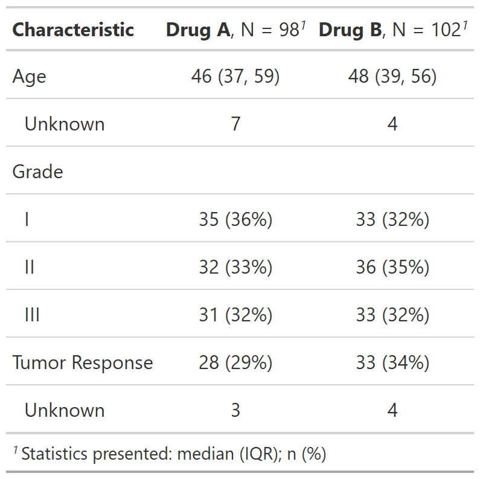

  ]

??? - Go slow here

- summarizing a data set is the MOST important analysis
- summarize data first! you will often catch mistakes. Data is complicated, and understanding it up front is important.
- Communicating a summary of the data ALONG with analytic results in necessary (others may catch mistakes you’re not aware of)
- {gtsummary} is for presenting results, other great packages are available for summarizing data for your self (e.g. skimr)
- just one line of code
- all functions beginning with `tbl_*` create a new tables
- this is how I used the package 95% percent of the time…so easy
- three types of data shown here (explain them)

# {gtsummary} and formulas

.large[

Many arguments use formula syntax (or list of formulas), and provide many options to easily select variables you want to modify.

.center[

*select variables* ~ specify what you want to do ]

- `label = list(age ~ "Patient Age", marker ~ "Marker Level Pre-Tx")`
- `type = c(age, marker) ~ "continuous"`
- `digits = list(age ~ 0, marker ~ 2)`
- `statistic = all_continuous() ~ "{median} [{min}, {max}]"`

]

??? - case_when uses similar syntax

# cross table with tbl_cross()

`tbl_cross()` is a wrapper for `tbl_summary()` for **n x m** tables

.pull-left[

```r
tbl_cross_1 <-
  sm_trial %>%
  tbl_cross(
    row = trt,
    col = grade,
    percent = "row",
    margin = "row"
  ) %>%
  add_p(source_note = TRUE)
```

]

.pull-right[

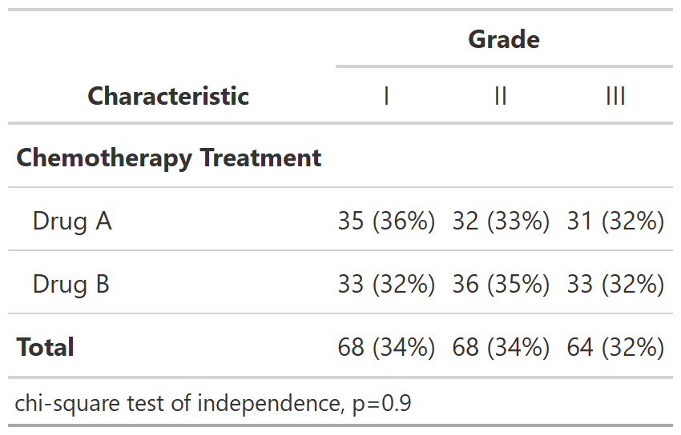

]